# Projet d’analyse des données

Ouahbi Haj Kacem

2022-12-25

## Présentation du projet

Voici les résultats obtenus à partir du questionnaire sur les sports individuels et collectifs intitulé “Team and individual sports”, les données contiennent quelques informations personnelles sur les personnes (sexe, âge…). puis leurs préférences concernant les différentes activités sportives et les différentes raisons pour lesquelles les personnes pratiquent différents sports. Le tableau de données contient 40 lignes (liées au nombre de personnes ayant répondu au questionnaire) et 37 colonnes (le nombre de questions). Les colonnes de 8 à 19 contiennent des variables quantitatives sur les préférences des personnes en matière de sports. Les colonnes de 20 à 34 contiennent des variables quantitatives sur les raisons pour lesquelles les gens font du sport. Les autres colonnes contiennent des variables qualitatives sur les individus telles que le sexe, la catégorie d’âge, la catégorie socioprofessionnelle, la fréquence de la pratique sportive…

## Analyse en composantes principales

L’analyse en composantes principales(ACP): C’est l’une des méthodes d’analyse de données multivariées les plus fréquemment utilisées. Elle permet d’étudier des ensembles de données multidimensionnelles avec des variables quantitatives. Elle est largement utilisée en biostatistique, en marketing, en sociologie et dans de nombreux autres domaines.

### L’objectif de l’ACP:

L’ACP permet de décrire un jeu de données, de le résumer, d’en réduire la dimensionnalité.

### 1. l’interet de l’ACP:

L’interet de l’acp en général est double : -Variable : regrouper les variables corrélées pour les remplacer par un petit nombre d’une nouvelle variable (composante principale) -Individus : regrouper les individus en des grouprs homogènes puis les décrire

### 2.Pertinence statistique de l’ACP:

Il foudrait que les variables aient un minimum correlation entre elles , comment le savoir? -> Matrice de corrélation

### 3. Choix du nombre d’axe à retenir :

On a 3 méthodes : - Critère de kaiser - Taux d’inertie cummulée - Critère du coude

### 4. Interprétation des axes :

- Cercle de corrélation
- Voir pour chaque axe quelles variables sont corrélées à cet axe
- Cos carré des variables

### 5. Interprétation des cartes des individus

## Importation et exploration du jeu de données et des packages

```r
library(readxl)
library(factoextra)
library(FactoMineR)
```

```r
library(corrplot)
sports <-read_excel("C:/Users/wahby/Desktop/Team and individual sports.xlsx")

dim(sports)
```

```
## [1] 40 37
```

On a 40 observations ou individus et 37 variables.

```r
# Pour afficher la liste des variables :
names(sports)
```

```
##  [1] "Sexe"
##  [2] "Categorie d'age"
##  [3] "Categorie_Socioprofessionnelle"
##  [4] "Sports individuels ou collectifs que vous pratiquez au moins 1 fois par mois ?"
##  [5] "A quelle frequence pratiquez-vous du sport  ?"
##  [6] "Quel budget global consacrez-vous chaque année à vos activités sportives ?\r\n(Abonnement à une salle, adhésion à un club, location de terrains de sports, achats d’équipements et matériels…)"
##  [7] "Ou pratiquez-vous du sport ?"
##  [8] "Futsal"
##  [9] "Football"
## [10] "Handball"
## [11] "Basketball"
## [12] "Tennis / Tennis de table"
## [13] "Hockey"
## [14] "Baseball"
## [15] "Padel"
```

[output cut: 22 more lines]

```r
summary(sports)
```

```
##      Sexe           Categorie d'age    Categorie_Socioprofessionnelle
##  Length:40          Length:40          Length:40
##  Class :character   Class :character   Class :character
##  Mode  :character   Mode  :character   Mode  :character
##
##
##
##  Sports individuels ou collectifs que vous pratiquez au moins 1 fois par mois ?
##  Length:40
##  Class :character
##  Mode  :character
##
##
##
##  A quelle frequence pratiquez-vous du sport  ?
##  Length:40
##  Class :character
##  Mode  :character
##
##
##
##  Quel budget global consacrez-vous chaque année à vos activités sportives ?\r\n(Abonnement à une salle, adhésion à un club, location de terrains de sports, achats d’équipements et matériels…)
##  Length:40
##  Class :character
##  Mode  :character
##
##
##
##  Ou pratiquez-vous du sport ?     Futsal         Football        Handball
##  Length:40                    Min.   :1.000   Min.   :1.000   Min.   :1.000
##  Class :character             1st Qu.:1.000   1st Qu.:2.000   1st Qu.:1.750
##  Mode  :character             Median :2.000   Median :4.000   Median :4.000
##                               Mean   :2.525   Mean   :3.325   Mean   :3.175
##                               3rd Qu.:4.000   3rd Qu.:5.000   3rd Qu.:4.250
##                               Max.   :5.000   Max.   :5.000   Max.   :5.000
##    Basketball    Tennis / Tennis de table     Hockey         Baseball
##  Min.   :1.000   Min.   :1.00             Min.   :1.000   Min.   :1.000
##  1st Qu.:2.000   1st Qu.:2.75             1st Qu.:1.000   1st Qu.:1.000
##  Median :3.000   Median :4.00             Median :1.000   Median :1.000
##  Mean   :2.975   Mean   :3.35             Mean   :1.625   Mean   :1.825
```

[output cut: 78 more lines]

```
##  Max.   :5.000
##  A quelle frequence moyenne pourriez-vous vous rendre dans ce complexe multisports ?
##  Length:40
##  Class :character
##  Mode  :character
##
##
##
##  Attentes_Des_Clients
##  Length:40
##  Class :character
##  Mode  :character
##
##
##
```

## ACP sur les différentes activités sportives et de Bien-être

On commence par définir la matrice diffSports composée des différentes activités sportives et de Bien-être

```r
diffSports=as.matrix(sports[, 8:19])
M1<-cor(diffSports)
M1
```

```
##                                     Futsal    Football   Handball  Basketball
## Futsal                           1.0000000  0.38978491 0.42059997  0.54840302
## Football                         0.3897849  1.00000000 0.28050767  0.29334311
## Handball                         0.4206000  0.28050767 1.00000000  0.44533232
## Basketball                       0.5484030  0.29334311 0.44533232  1.00000000
## Tennis / Tennis de table         0.3071684  0.20628030 0.69294174  0.50787697
## Hockey                           0.4612339  0.34325116 0.31997937  0.13907403
## Baseball                         0.4582811  0.33887315 0.22050863  0.19719966
## Padel                            0.5161745  0.04230668 0.19172162  0.44431478
## Pétanque                         0.4980982  0.36645400 0.29825663  0.20664730
## Golf                             0.2734508  0.24356358 0.02930335  0.10395240
## Fitness                         -0.3031197 -0.08931895 0.18943795  0.07297144
## Zumba ou autre danses sportives -0.3093800 -0.25801556 0.05777331 -0.18400474
##                                 Tennis / Tennis de table    Hockey  Baseball
## Futsal                                        0.30716845 0.4612339 0.4582811
## Football                                      0.20628030 0.3432512 0.3388731
## Handball                                      0.69294174 0.3199794 0.2205086
## Basketball                                    0.50787697 0.1390740 0.1971997
## Tennis / Tennis de table                      1.00000000 0.2103848 0.1635178
## Hockey                                        0.21038481 1.0000000 0.8191979
## Baseball                                      0.16351775 0.8191979 1.0000000
## Padel                                         0.20670633 0.3654759 0.4313495
## Pétanque                                      0.22117164 0.8931431 0.9600718
## Golf                                          0.17248434 0.7232467 0.8714506
## Fitness                                       0.24663948 0.1201900 0.1358733
## Zumba ou autre danses sportives               0.09278464 0.1792145 0.1300628
##                                      Padel   Pétanque       Golf     Fitness
## Futsal                          0.51617448 0.49809824 0.27345084 -0.30311969
## Football                        0.04230668 0.36645400 0.24356358 -0.08931895
## Handball                        0.19172162 0.29825663 0.02930335  0.18943795
## Basketball                      0.44431478 0.20664730 0.10395240  0.07297144
## Tennis / Tennis de table        0.20670633 0.22117164 0.17248434  0.24663948
## Hockey                          0.36547586 0.89314313 0.72324668  0.12018996
## Baseball                        0.43134952 0.96007180 0.87145064  0.13587334
## Padel                           1.00000000 0.41284127 0.26887607  0.17590320
## Pétanque                        0.41284127 1.00000000 0.82707931  0.09191508
## Golf                            0.26887607 0.82707931 1.00000000  0.06623042
## Fitness                         0.17590320 0.09191508 0.06623042  1.00000000
## Zumba ou autre danses sportives 0.15482094 0.07325104 0.10632292  0.81769193
##                                 Zumba ou autre danses sportives
## Futsal                                              -0.30937998
## Football                                            -0.25801556
## Handball                                             0.05777331
## Basketball                                          -0.18400474
## Tennis / Tennis de table                             0.09278464
## Hockey                                               0.17921449
## Baseball                                             0.13006279
## Padel                                                0.15482094
## Pétanque                                             0.07325104
## Golf                                                 0.10632292
## Fitness                                              0.81769193
## Zumba ou autre danses sportives                      1.00000000
```

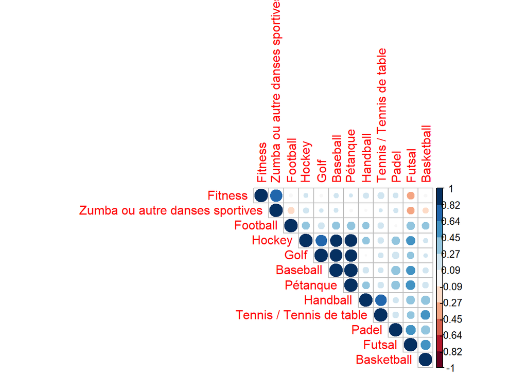

```r
library(RColorBrewer)
corrplot(M1, type="upper", order="hclust",
         col=brewer.pal(n=11, name="RdBu"))
```

Le corrgram donné ci-dessus permet d’étudier les corrélations entre les variables quantitatives : il est clair qu’il existe des corrélations entre des groupes de variables ce qui suggère la pertinence de cette ACP (par exemple, Futsal, Basketball et Football).

Par la suite, nous voulons choisir le nombre d’axes à retenir.

```r
res.pca=PCA(diffSports, quali.sup=1:3, graph=F)
res.pca$eig
```

```
##        eigenvalue percentage of variance cumulative percentage of variance
## comp 1 3.97736480             44.1929422                          44.19294
## comp 2 1.80794264             20.0882516                          64.28119
## comp 3 1.51973419             16.8859355                          81.16713
## comp 4 0.77148052              8.5720057                          89.73914
## comp 5 0.37490044              4.1655604                          93.90470
## comp 6 0.27870026              3.0966696                          97.00137
## comp 7 0.15847847              1.7608719                          98.76224
## comp 8 0.09248310              1.0275900                          99.78983
## comp 9 0.01891558              0.2101731                         100.00000
```

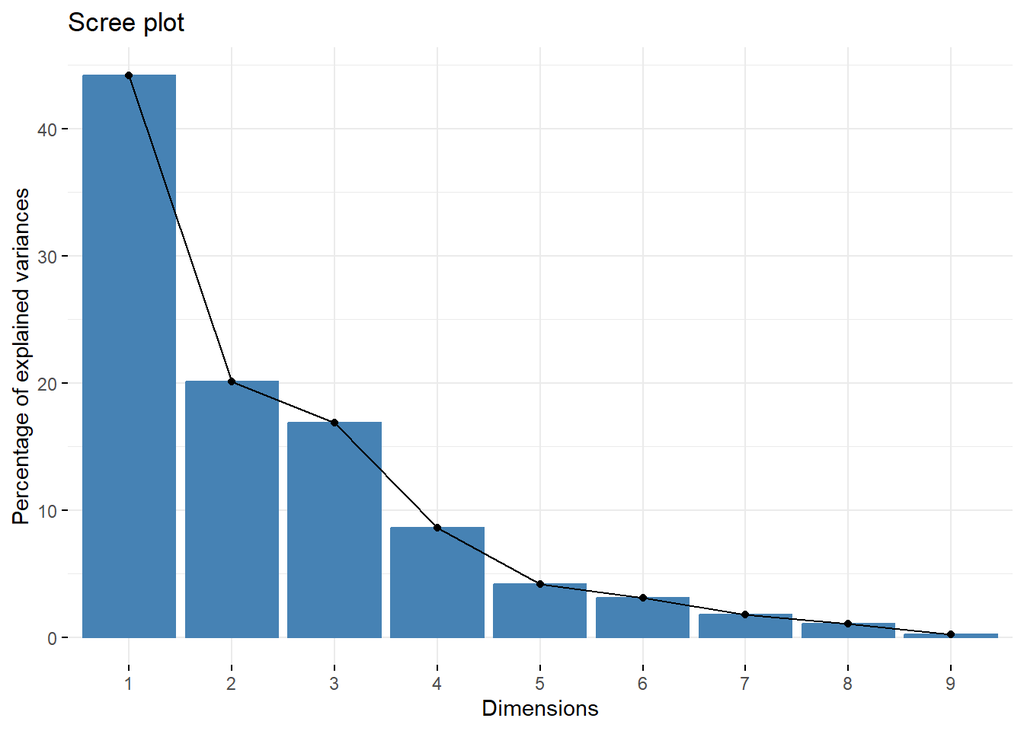

```r
fviz_screeplot(res.pca)
```

Critère de kaiser : on remarque qu’il y a 3 axes dont les valeurs propres sont supérieures à 1 donc on retient 3 axes d’après ce critère.

Critère du taux d’inertie cumulée : On remarque que le taux d’inertie cumulé des 2 premiers axes est de 64.28% qui est un taux important compte tenu du fait que nous avons 9 variables : on va donc, d’après ce critère, retenir les 2 premiers axes.

Critère du coude : On remarque que le coude se trouve au niveau du deuxième axe (voir la figure Scree plot), d’après ce critère, on devrait retenir les 2 premiers axes.

En faisant une sorte de vote des 3 critères on devrait retenir les 2 premiers axes.

## Interprétation de la carte des variables :

```r
names(res.pca$var)
```

```
## [1] "coord"   "cor"     "cos2"    "contrib"
```

```r
# L’objet var de res.pca contient les 4 objets : coord, cor, cos2 et contrib. A noter que vu que notre ACP est normée, cor (i.e. la corrélations d’une variable avec la composante principale d’un axe) est identique à coord (i.e. la coordonnée de cette variable sur cet axe).
```

```r
res.pca$var$coord
```

```
##                                     Dim.1       Dim.2       Dim.3       Dim.4
## Basketball                      0.3354034 -0.04587029  0.84902740 -0.06395868
## Tennis / Tennis de table        0.3593565  0.22873695  0.65489679  0.53716411
## Hockey                          0.8854008 -0.10517318 -0.18346946  0.06017235
## Baseball                        0.9437024 -0.15231760 -0.17393223 -0.01671561
## Padel                           0.5568251  0.11101788  0.38728503 -0.66930514
## Pétanque                        0.9477695 -0.19735537 -0.13833584  0.04027491
## Golf                            0.8518298 -0.18818057 -0.24000246  0.15025034
## Fitness                         0.2638540  0.91416425 -0.02353416  0.02984625
## Zumba ou autre danses sportives 0.2401445  0.89267778 -0.28071670 -0.04343955
##                                       Dim.5
## Basketball                       0.37388758
## Tennis / Tennis de table        -0.30847991
## Hockey                          -0.10959901
## Baseball                         0.09560314
## Padel                           -0.26080757
## Pétanque                         0.01165428
## Golf                             0.09983723
## Fitness                          0.19684593
## Zumba ou autre danses sportives -0.04386969
```

```r
# L’objet coord dans var contient les coordonnées des variables.
```

```r
res.pca$var$cos2
```

```
##                                      Dim.1       Dim.2        Dim.3
## Basketball                      0.11249547 0.002104083 0.7208475230
## Tennis / Tennis de table        0.12913711 0.052320591 0.4288898041
## Hockey                          0.78393453 0.011061397 0.0336610432
## Baseball                        0.89057422 0.023200651 0.0302524205
## Padel                           0.31005414 0.012324970 0.1499896940
## Pétanque                        0.89826701 0.038949142 0.0191368043
## Golf                            0.72561402 0.035411926 0.0576011809
## Fitness                         0.06961892 0.835696272 0.0005538567
## Zumba ou autre danses sportives 0.05766937 0.796873610 0.0788018670
##                                        Dim.4        Dim.5
## Basketball                      0.0040907131 0.1397919240
## Tennis / Tennis de table        0.2885452829 0.0951598566
## Hockey                          0.0036207113 0.0120119439
## Baseball                        0.0002794117 0.0091399607
## Padel                           0.4479693713 0.0680205871
## Pétanque                        0.0016220680 0.0001358223
## Golf                            0.0225751641 0.0099674722
## Fitness                         0.0008907987 0.0387483191
## Zumba ou autre danses sportives 0.0018869947 0.0019245495
```

```r
# L’objet cos2 dans var est une matrice dont les lignes représentent le cos carrés de la variable
```

### Représentation de la carte des variables :

La représentation des variables dans le plan factoriel permet d’évaluer la liaison entre les variables.

Plus l’angle entre deux variables est petit, plus la corrélation est proche de 1. Si l’angle est droit, la corrélation est proche de 0. Si l’angle est de 180° (les flèches sont opposées) alors la corrélation est proche de -1. tout ça est s’applique évidemment si les variables sont “bien représentées” par les deux premiers axes de l’ACP

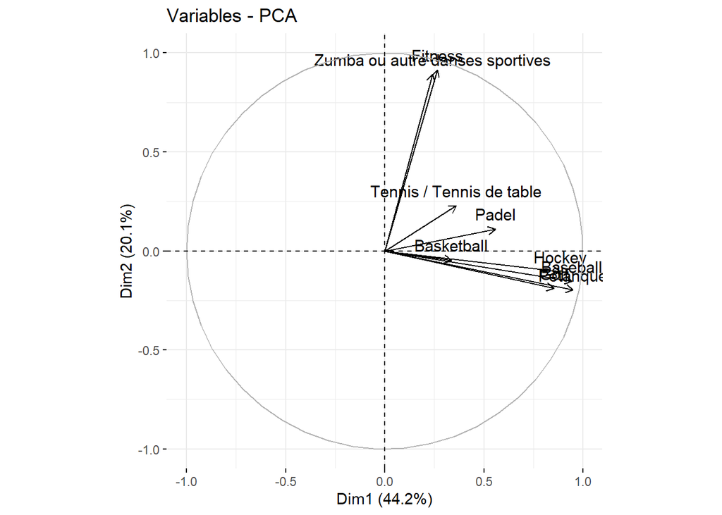

```r
fviz_pca_var(res.pca)
```

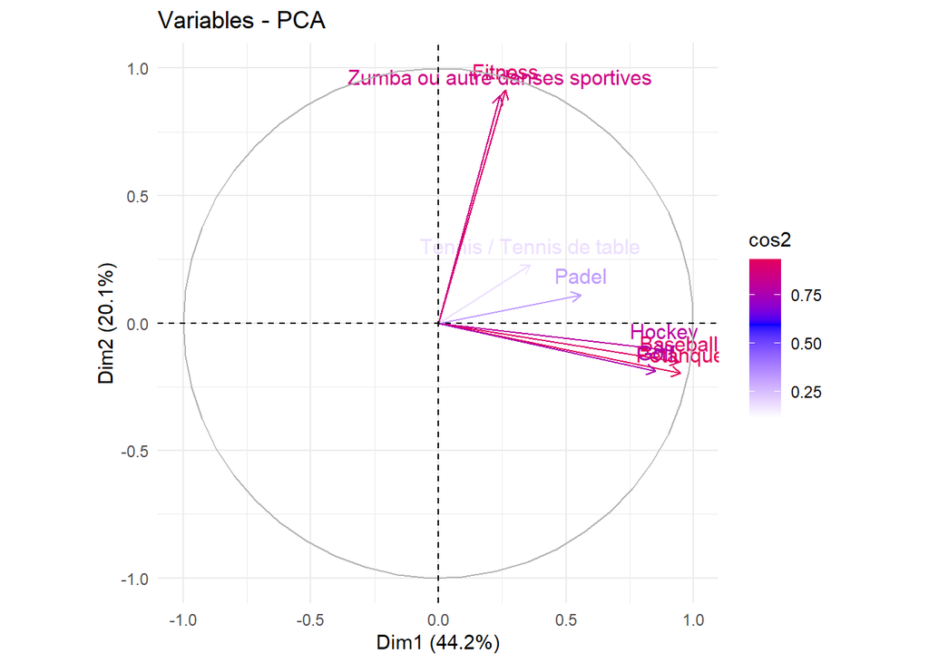

```r
fviz_pca_var(res.pca, col.var="cos2") +
  scale_color_gradient2(low="white", mid="blue",
                        high="red", midpoint=0.6) +
  theme_minimal()
```

La qualité de la représentation d’une variable par un axe peut être évaluée par le cosinus au carré de l’angle entre la variable et l’axe considéré. Le cosinus correspond à la projection orthogonale de la flèche sur l’axe. Ainsi, la qualité de la représentation sur les deux axes (c’est-à-dire la somme des cosinus au carré) correspond à la longueur de la flèche : plus la pointe de la flèche est proche du cercle, meilleure est la représentation de la variable dans le plan factoriel.

### Représentation de la carte des individus :

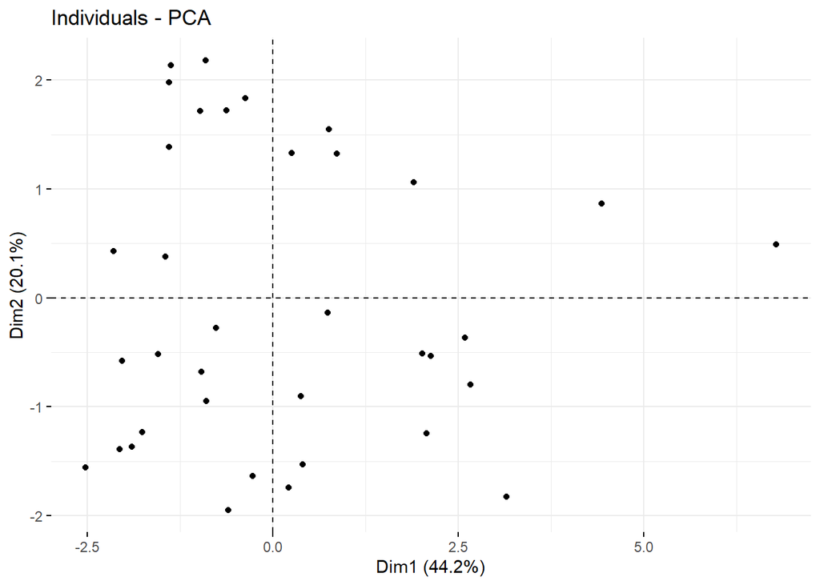

```r
fviz_pca_ind(res.pca,geom = "point",col.ind.sup = 'gray')
```

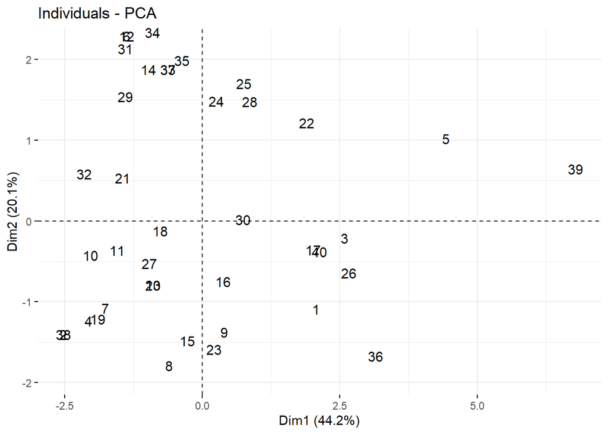

```r
fviz_pca_ind(res.pca,geom = "text",col.ind.sup = 'gray')
```

Les deux graphiques ci-dessus montrent les ” ressemblances ” entre les individus. Plus ils sont proches les uns des autres (par exemple, l’individu 12 et l’individu 6, en haut à gauche, ou les individus 7, 4 et 19, en bas à gauche), plus leurs choix et préférences en matière d’activités sportives sont susceptibles d’être similaires.

Comme dans le cas des variables, les individus les mieux représentés par le plan factoriel sont ceux les plus éloignés du centre (même si ici on ne peut pas lire directement les valeurs de cosinus sur le graphique - elles sont en revanche disponible dans l’objet res.pca issu de l’ACP).

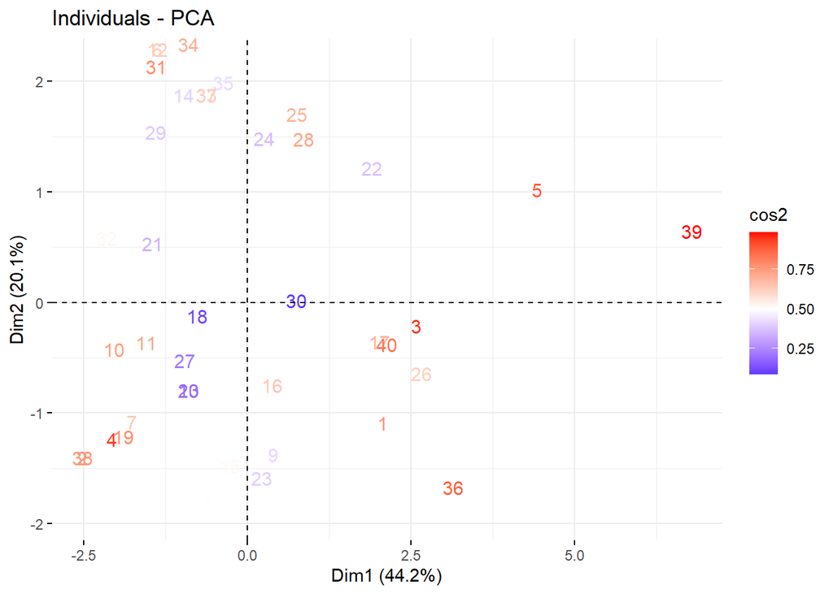

```r
fviz_pca_ind(res.pca,geom = "text",col.ind="cos2")+
scale_color_gradient2(low="blue", mid="white",
                      high="red", midpoint=0.5)
```

Notons que la qualité de représentation d’un individu sur le premier plan est donnée par la somme de ses cos2 sur chacun des 2 premiers axes.

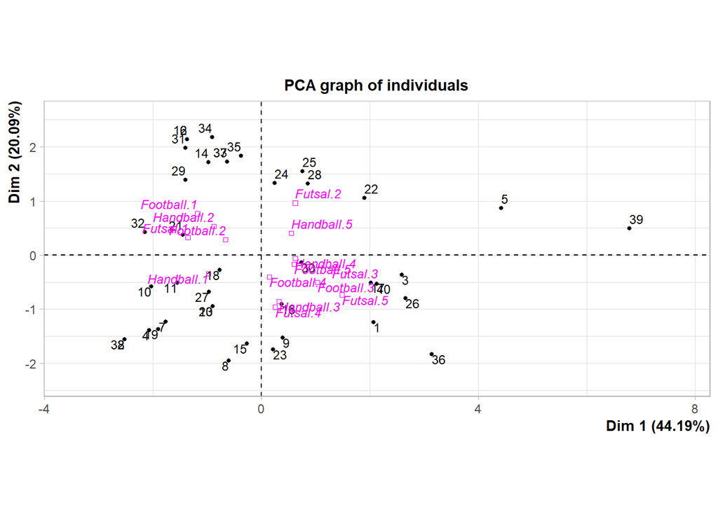

```r
plot.PCA(res.pca, axes=c(1, 2), choix="ind", cex=0.8)
```

## ACP sur les différentes raisons de pratiquer des activités sportives et de bien-être

On commence par définir la matrice diffRaisons composée des différents raisons de pratiquer des activités sportives et de bien-être

```r
diffRaisons=as.matrix(sports[, 20:34])
M2<-cor(diffRaisons)
M2
```

```
##                                                              Pour maigrir
## Pour maigrir                                                   1.00000000
## Pour perdre du poids                                           1.00000000
## Pour bruler les graisses                                       0.87945096
## Pour se maintenir en forme                                     0.24090786
## Pour permettre au cerveau de fonctionner de maniere optimale  -0.18342547
## Pour developper les muscles secs                               0.42031268
## Pour se sentir seduisant                                       0.02088828
## Pour diminuer son stress                                       0.07483881
## Pour se faire plaisir                                          0.33522321
## Pour rencontrer d'autres personnes                             0.10597328
## Par amour de la competition                                   -0.40383411
## Pour reduire les risques de contracter une maladie chronique   0.19999778
## Pour stimuler sa creativite                                    0.20768497
## Pour booster son énergie]                                      0.01750284
## Pour avoir plus de confiance en soi                           -0.14803218
##                                                              Pour perdre du poids
## Pour maigrir                                                           1.00000000
## Pour perdre du poids                                                   1.00000000
## Pour bruler les graisses                                               0.87945096
## Pour se maintenir en forme                                             0.24090786
## Pour permettre au cerveau de fonctionner de maniere optimale          -0.18342547
## Pour developper les muscles secs                                       0.42031268
## Pour se sentir seduisant                                               0.02088828
## Pour diminuer son stress                                               0.07483881
## Pour se faire plaisir                                                  0.33522321
## Pour rencontrer d'autres personnes                                     0.10597328
## Par amour de la competition                                           -0.40383411
## Pour reduire les risques de contracter une maladie chronique           0.19999778
## Pour stimuler sa creativite                                            0.20768497
## Pour booster son énergie]                                              0.01750284
## Pour avoir plus de confiance en soi                                   -0.14803218
##                                                              Pour bruler les graisses
## Pour maigrir                                                             0.8794509585
## Pour perdre du poids                                                     0.8794509585
## Pour bruler les graisses                                                 1.0000000000
## Pour se maintenir en forme                                               0.3501106333
## Pour permettre au cerveau de fonctionner de maniere optimale             0.0007947777
## Pour developper les muscles secs                                         0.4170556527
## Pour se sentir seduisant                                                 0.1261765710
```

[output cut: 185 more lines]

```
## Pour maigrir                                                                        -0.148032184
## Pour perdre du poids                                                                -0.148032184
## Pour bruler les graisses                                                            -0.160874129
## Pour se maintenir en forme                                                          -0.183785979
## Pour permettre au cerveau de fonctionner de maniere optimale                        -0.033608433
## Pour developper les muscles secs                                                    -0.155040507
## Pour se sentir seduisant                                                            -0.002196614
## Pour diminuer son stress                                                            -0.136528444
## Pour se faire plaisir                                                               -0.140632136
## Pour rencontrer d'autres personnes                                                   0.254514742
## Par amour de la competition                                                          0.370214545
## Pour reduire les risques de contracter une maladie chronique                         0.046108170
## Pour stimuler sa creativite                                                          0.296643952
## Pour booster son énergie]                                                            0.386391503
## Pour avoir plus de confiance en soi                                                  1.000000000
```

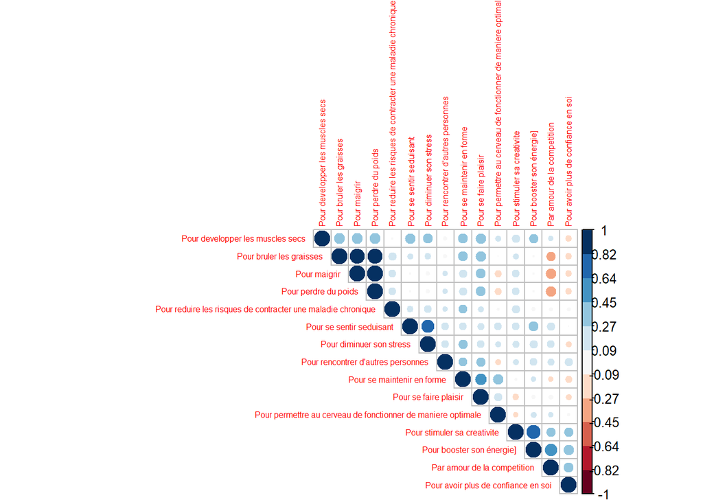

```r
library(RColorBrewer)
corrplot(M2, type="upper", order="hclust", tl.cex = 0.5,
         col=brewer.pal(n=11, name="RdBu"))
```

Le corrgramme donné ci-dessus nous permet d’étudier les corrélations entre les variables quantitatives : il est clair qu’il existe des corrélations entre des groupes de variables ce qui suggère la pertinence de cette ACP (par exemple, Par amour de la compétition, pour avoir plus de confiance en soi, …).

Après cela, nous ferons le choix du nombre d’axes à retenir.

```r
res1.pca=PCA(diffRaisons, quali.sup=1:3, graph=F)
res1.pca$eig
```

```
##         eigenvalue percentage of variance cumulative percentage of variance
## comp 1   3.1865076              26.554230                          26.55423
## comp 2   2.2609907              18.841589                          45.39582
## comp 3   1.2628171              10.523476                          55.91929
## comp 4   1.1496631               9.580526                          65.49982
## comp 5   1.0007366               8.339472                          73.83929
## comp 6   0.9145664               7.621387                          81.46068
## comp 7   0.5376167               4.480139                          85.94082
## comp 8   0.5234182               4.361818                          90.30264
## comp 9   0.4139399               3.449499                          93.75214
## comp 10  0.3363256               2.802713                          96.55485
## comp 11  0.2696654               2.247212                          98.80206
## comp 12  0.1437528               1.197940                         100.00000
```

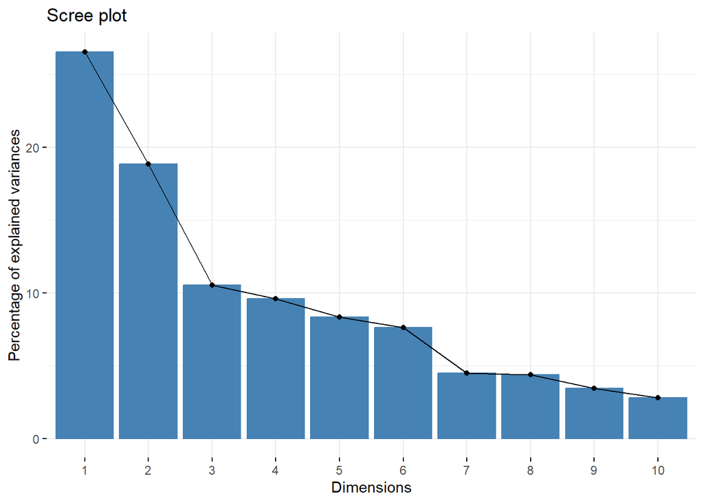

```r
fviz_screeplot(res1.pca)
```

Critère de kaiser : on remarque qu’il y a 5 axes dont les valeurs propres sont supérieures à 1 donc on retient 5 axes d’après ce critère.

Critère du taux d’inertie cumulée : On remarque que le taux d’inertie cumulé des 3 premiers axes est de 55.9% qui est un taux important compte tenu du fait que nous avons 12 variables : on va donc, d’après ce critère, retenir les 3 premiers axes.

Critère du coude : On remarque que le coude se trouve au niveau du deuxième axe (voir la figure Scree plot), d’après ce critère, on devrait retenir les 2 premiers axes.

En faisant une sorte de vote des 3 critères on devrait retenir les 2 premiers axes.

```r
names(res1.pca$var)
```

```
## [1] "coord"   "cor"     "cos2"    "contrib"
```

```r
# L’objet var de res.pca contient les 4 objets : coord, cor, cos2 et contrib. A noter que vu que notre ACP est normée, cor (i.e. la corrélations d’une variable avec la composante principale d’un axe) est identique à coord (i.e. la coordonnée de cette variable sur cet axe).
```

```r
res1.pca$var$coord
```

```
##                                                                  Dim.1
## Pour se maintenir en forme                                   0.4914394
## Pour permettre au cerveau de fonctionner de maniere optimale 0.2886398
## Pour developper les muscles secs                             0.6038840
## Pour se sentir seduisant                                     0.7010449
## Pour diminuer son stress                                     0.6805324
## Pour se faire plaisir                                        0.4024505
## Pour rencontrer d'autres personnes                           0.4382821
## Par amour de la competition                                  0.4866721
## Pour reduire les risques de contracter une maladie chronique 0.3034596
## Pour stimuler sa creativite                                  0.5459949
## Pour booster son énergie]                                    0.7261187
## Pour avoir plus de confiance en soi                          0.1845638
##                                                                    Dim.2
## Pour se maintenir en forme                                   -0.59777346
## Pour permettre au cerveau de fonctionner de maniere optimale -0.31860127
## Pour developper les muscles secs                             -0.27703578
## Pour se sentir seduisant                                     -0.11588483
## Pour diminuer son stress                                     -0.22759979
## Pour se faire plaisir                                        -0.58665592
## Pour rencontrer d'autres personnes                            0.01230687
## Par amour de la competition                                   0.55236577
## Pour reduire les risques de contracter une maladie chronique -0.11740455
## Pour stimuler sa creativite                                   0.55899639
## Pour booster son énergie]                                     0.49445848
## Pour avoir plus de confiance en soi                           0.66332227
##                                                                   Dim.3
## Pour se maintenir en forme                                    0.1935729
## Pour permettre au cerveau de fonctionner de maniere optimale -0.4488643
## Pour developper les muscles secs                             -0.2479204
## Pour se sentir seduisant                                     -0.2310739
## Pour diminuer son stress                                     -0.1383147
## Pour se faire plaisir                                         0.2743860
## Pour rencontrer d'autres personnes                            0.6680349
## Par amour de la competition                                  -0.2002047
## Pour reduire les risques de contracter une maladie chronique  0.4702655
## Pour stimuler sa creativite                                   0.0161399
## Pour booster son énergie]                                    -0.1023549
## Pour avoir plus de confiance en soi                           0.3104030
##                                                                   Dim.4
```

[output cut: 10 more lines]

```
## Pour booster son énergie]                                     0.1058471
## Pour avoir plus de confiance en soi                           0.3726904
##                                                                    Dim.5
## Pour se maintenir en forme                                    0.28164610
## Pour permettre au cerveau de fonctionner de maniere optimale  0.43861134
## Pour developper les muscles secs                             -0.12544058
## Pour se sentir seduisant                                     -0.23602951
## Pour diminuer son stress                                     -0.26018802
## Pour se faire plaisir                                        -0.07541765
## Pour rencontrer d'autres personnes                           -0.40919840
## Par amour de la competition                                  -0.11867869
## Pour reduire les risques de contracter une maladie chronique  0.56128460
## Pour stimuler sa creativite                                   0.23022368
## Pour booster son énergie]                                     0.14080680
## Pour avoir plus de confiance en soi                           0.12166938
```

```r
# L’objet coord dans var contient les coordonnées des variables.
```

```r
res1.pca$var$cos2
```

```
##                                                                   Dim.1
## Pour se maintenir en forme                                   0.24151265
## Pour permettre au cerveau de fonctionner de maniere optimale 0.08331294
## Pour developper les muscles secs                             0.36467589
## Pour se sentir seduisant                                     0.49146402
## Pour diminuer son stress                                     0.46312440
## Pour se faire plaisir                                        0.16196640
## Pour rencontrer d'autres personnes                           0.19209124
## Par amour de la competition                                  0.23684972
## Pour reduire les risques de contracter une maladie chronique 0.09208776
## Pour stimuler sa creativite                                  0.29811046
## Pour booster son énergie]                                    0.52724835
## Pour avoir plus de confiance en soi                          0.03406380
##                                                                    Dim.2
## Pour se maintenir en forme                                   0.357333115
## Pour permettre au cerveau de fonctionner de maniere optimale 0.101506768
## Pour developper les muscles secs                             0.076748826
## Pour se sentir seduisant                                     0.013429293
## Pour diminuer son stress                                     0.051801663
## Pour se faire plaisir                                        0.344165167
## Pour rencontrer d'autres personnes                           0.000151459
## Par amour de la competition                                  0.305107942
## Pour reduire les risques de contracter une maladie chronique 0.013783829
## Pour stimuler sa creativite                                  0.312476967
## Pour booster son énergie]                                    0.244489193
## Pour avoir plus de confiance en soi                          0.439996432
##                                                                     Dim.3
## Pour se maintenir en forme                                   0.0374704596
## Pour permettre au cerveau de fonctionner de maniere optimale 0.2014791226
## Pour developper les muscles secs                             0.0614645419
## Pour se sentir seduisant                                     0.0533951342
## Pour diminuer son stress                                     0.0191309626
## Pour se faire plaisir                                        0.0752876703
## Pour rencontrer d'autres personnes                           0.4462706093
## Par amour de la competition                                  0.0400819233
## Pour reduire les risques de contracter une maladie chronique 0.2211496645
## Pour stimuler sa creativite                                  0.0002604964
## Pour booster son énergie]                                    0.0104765208
## Pour avoir plus de confiance en soi                          0.0963499956
##                                                                   Dim.4
```

[output cut: 10 more lines]

```
## Pour booster son énergie]                                    0.01120360
## Pour avoir plus de confiance en soi                          0.13889811
##                                                                    Dim.5
## Pour se maintenir en forme                                   0.079324523
## Pour permettre au cerveau de fonctionner de maniere optimale 0.192379903
## Pour developper les muscles secs                             0.015735340
## Pour se sentir seduisant                                     0.055709929
## Pour diminuer son stress                                     0.067697804
## Pour se faire plaisir                                        0.005687823
## Pour rencontrer d'autres personnes                           0.167443327
## Par amour de la competition                                  0.014084630
## Pour reduire les risques de contracter une maladie chronique 0.315040398
## Pour stimuler sa creativite                                  0.053002943
## Pour booster son énergie]                                    0.019826554
## Pour avoir plus de confiance en soi                          0.014803438
```

```r
# L’objet cos2 dans var est une matrice dont les lignes représentent le cos carrés de la variable.
```

La représentation des variables dans le plan factoriel permet d’évaluer la liaison.

### Représentation de la carte des variables :

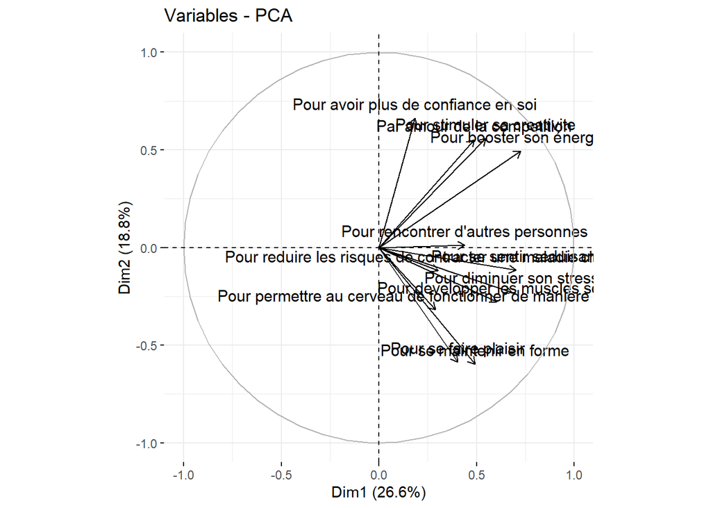

```r
fviz_pca_var(res1.pca)
```

Dans notre cas, les variables “Pour booster son énergie”, “Pour se maintenir en forme”, “Pour stimuler sa créativité” sont assez proches du cercle de corrélation et sont donc les mieux représentées sur le mapping.

Les angles plutôt fermés (en partant de l’origine) que forment les points “Pour se sentir séduisant”, “Pour diminuer son stress” et “Pour développer les muscles secs” indique que ces 3 variables sont assez bien corrélées entre elles. De meme pour les variables “Pour booster son énergie”, “Pour stimuler sa créativité” et “Par amour de la compétition” qui ont une angle très petite entre elles donc elles sont bien corrélées.

En ce qui concerne l’axe 2, la variable “Pour avoir plus de confiance en soi” est très bien corrélé avec l’axe. La variable “Pour se maintenir en forme” le sont également mais dans une moindre mesure.

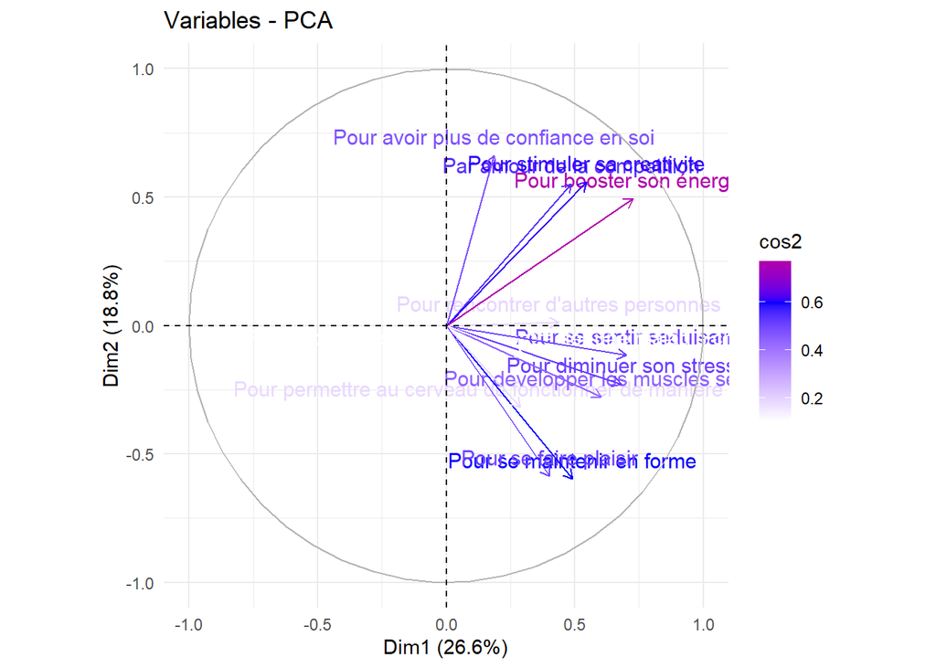

```r
fviz_pca_var(res1.pca, col.var="cos2") +
  scale_color_gradient2(low="white", mid="blue",
                        high="red", midpoint=0.6) +
  theme_minimal()
```

Notons que la qualité de la représentation d’une variable par un axe peut être évaluée par le cosinus au carré de l’angle entre la variable et l’axe considéré. Le cosinus correspond à la projection orthogonale de la flèche sur l’axe. Ainsi, la qualité de la représentation sur les deux axes (c’est-à-dire la somme des cosinus au carré) correspond à la longueur de la flèche : plus la pointe de la flèche est proche du cercle, meilleure est la représentation de la variable dans le plan factoriel.

### Représentation de la carte des individus :

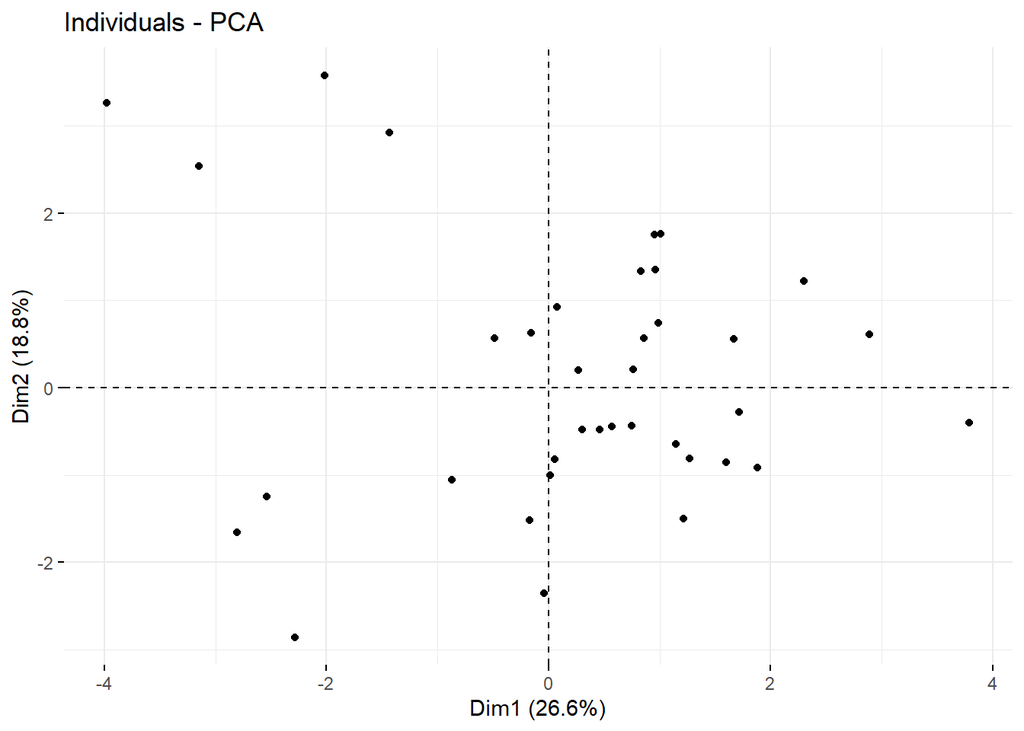

```r
fviz_pca_ind(res1.pca,geom = "point",col.ind.sup = 'gray')
```

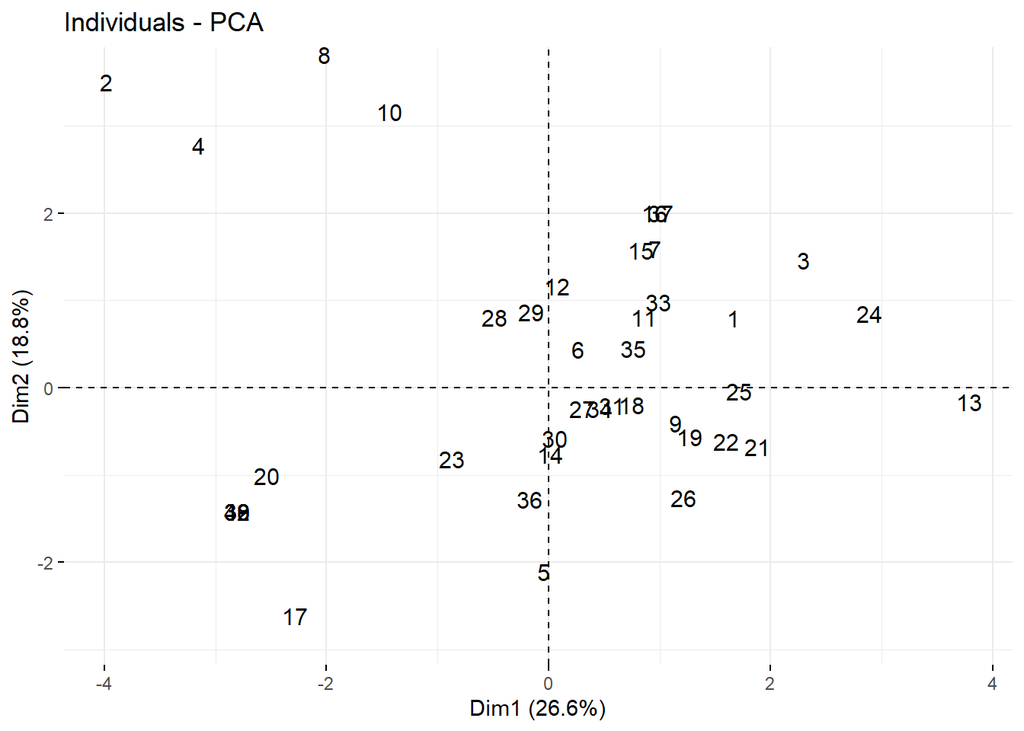

```r
fviz_pca_ind(res1.pca,geom = "text",col.ind.sup = 'gray')
```

Les deux graphiques ci-dessus montrent les ” ressemblances ” entre les individus. Plus ils sont proches les uns des autres (par exemple, l’individu 30 et l’individu 14), plus leurs raisons de pratiquer les d’activités sportives sont susceptibles d’être similaires.

Comme dans le cas des variables, les individus les mieux représentés par le plan factoriel sont ceux les plus éloignés du centre (même si ici on ne peut pas lire directement les valeurs de cosinus sur le graphique - elles sont en revanche disponible dans l’objet res.pca issu de l’ACP).

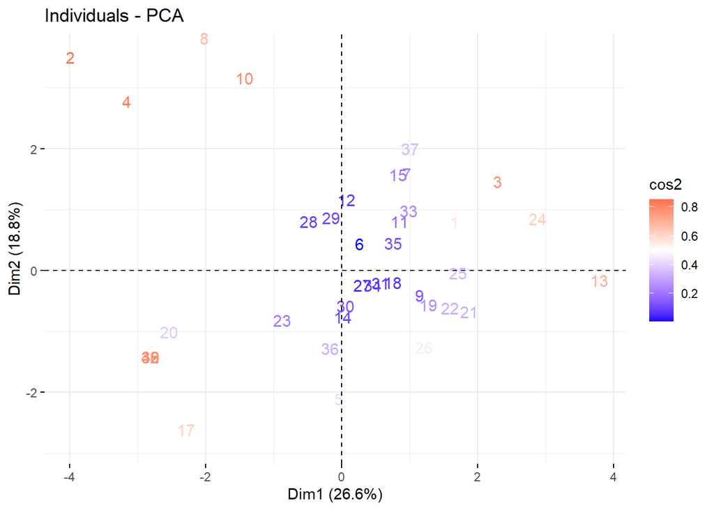

```r
fviz_pca_ind(res1.pca,geom = "text",col.ind="cos2")+
scale_color_gradient2(low="blue", mid="white",
                      high="red", midpoint=0.5)
```

Notons que la qualité de représentation d’un individu sur le premier plan est donnée par la somme de ses cos2 sur chacun des 2 premiers axes.

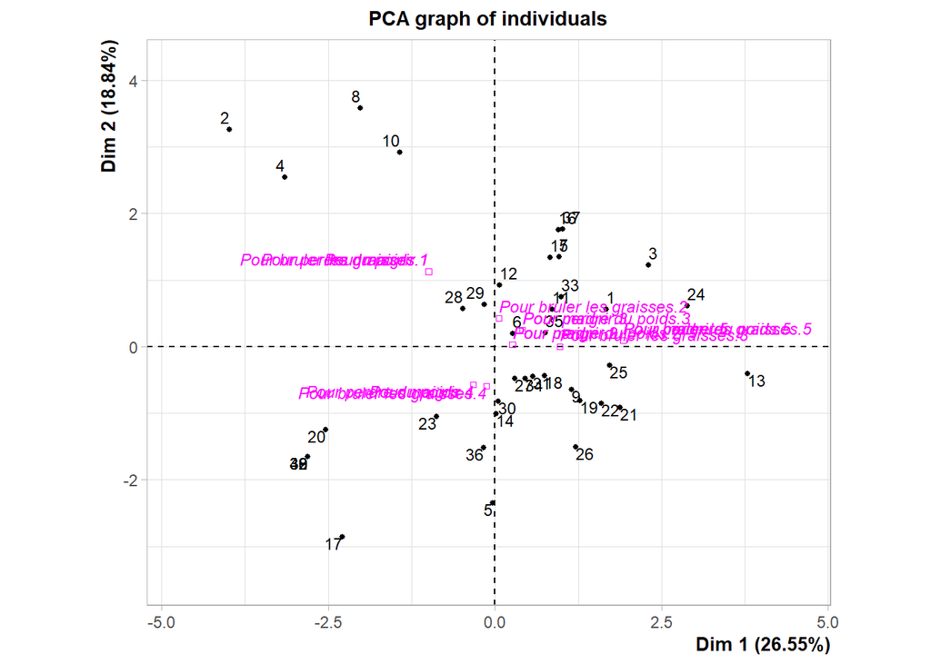

```r
plot.PCA(res1.pca, axes=c(1, 2), choix="ind", cex=0.8)
```

## Analyse Factorielle des Correspondances

On va effectuer une AFC sur les deux variables qualitatives (Catégorie d’age , la fréquence sportive)

```r
#1. Introduction du tableau :
# Tableau croisée des effectifs et des fréquences :
tab<-table(sports$`Categorie d'age`, sports$`A quelle frequence pratiquez-vous du sport  ?`)

# Tableau de contingence
addmargins(tab)
```

```
##
##                      1 à 2 fois par semaine 3 à 4 fois par semaine
##   Entre 18 et 25 ans                      7                      2
##   Entre 25 et 50 ans                      3                      1
##   Moins de 18 ans                         4                      1
##   Plus de 50 ans                          0                      0
##   Sum                                    14                      4
##
##                      Tous les 15 jours Tous les jours ou presque Tous les mois
##   Entre 18 et 25 ans                 1                         1             8
##   Entre 25 et 50 ans                 3                         2             1
##   Moins de 18 ans                    0                         1             2
##   Plus de 50 ans                     0                         1             2
##   Sum                                4                         5            13
##
##                      Sum
##   Entre 18 et 25 ans  19
##   Entre 25 et 50 ans  10
##   Moins de 18 ans      8
##   Plus de 50 ans       3
##   Sum                 40
```

### Tableaux des profils :

```r
library(questionr)
#Tableau des profils-lignes
lprop(tab)
```

```
##
##                      1 à 2 fois par semaine 3 à 4 fois par semaine
##   Entre 18 et 25 ans  36.8                   10.5
##   Entre 25 et 50 ans  30.0                   10.0
##   Moins de 18 ans     50.0                   12.5
##   Plus de 50 ans       0.0                    0.0
##   Ensemble            35.0                   10.0
##
##                      Tous les 15 jours Tous les jours ou presque Tous les mois
##   Entre 18 et 25 ans   5.3               5.3                      42.1
##   Entre 25 et 50 ans  30.0              20.0                      10.0
##   Moins de 18 ans      0.0              12.5                      25.0
##   Plus de 50 ans       0.0              33.3                      66.7
##   Ensemble            10.0              12.5                      32.5
##
##                      Total
##   Entre 18 et 25 ans 100.0
##   Entre 25 et 50 ans 100.0
##   Moins de 18 ans    100.0
##   Plus de 50 ans     100.0
##   Ensemble           100.0
```

```r
#Tableau des profils-colonnes
cprop(tab)
```

```
##
##                      1 à 2 fois par semaine 3 à 4 fois par semaine
##   Entre 18 et 25 ans  50.0                   50.0
##   Entre 25 et 50 ans  21.4                   25.0
##   Moins de 18 ans     28.6                   25.0
##   Plus de 50 ans       0.0                    0.0
##   Total              100.0                  100.0
##
##                      Tous les 15 jours Tous les jours ou presque Tous les mois
##   Entre 18 et 25 ans  25.0              20.0                      61.5
##   Entre 25 et 50 ans  75.0              40.0                       7.7
##   Moins de 18 ans      0.0              20.0                      15.4
##   Plus de 50 ans       0.0              20.0                      15.4
##   Total              100.0             100.0                     100.0
##
##                      Ensemble
##   Entre 18 et 25 ans  47.5
##   Entre 25 et 50 ans  25.0
##   Moins de 18 ans     20.0
##   Plus de 50 ans       7.5
##   Total              100.0
```

D’après le tableau des profils colonnes, on constate que 75% des personnes qui pratiquent du sport tous les 15 jours sont entre 25 et 50 ans et 61% des personnes qui pratiquent su sport tout les mois sont entre 18 et 25 ans.

### Test de khi-deux :

```r
test<-chisq.test(tab)
test
```

```
##
##  Pearson's Chi-squared test
##
## data:  tab
## X-squared = 13.137, df = 12, p-value = 0.3592
```

La valeur du χ2 est de 13.137 la p-valeur est 0.3592

### Exécution de l’AFC :

```r
tab<-table(sports$`Categorie d'age`, sports$`A quelle frequence pratiquez-vous du sport  ?`)
res.ca<-CA(tab,graph=F)
summary(res.ca)
```

```
##
## Call:
## CA(X = tab, graph = F)
##
## The chi square of independence between the two variables is equal to 13.13652 (p-value =  0.3591962 ).
##
## Eigenvalues
##                        Dim.1   Dim.2   Dim.3
## Variance               0.204   0.098   0.026
## % of var.             62.137  29.881   7.982
## Cumulative % of var.  62.137  92.018 100.000
##
## Rows
##                             Iner*1000     Dim.1     ctr    cos2     Dim.2
## Entre 18 et 25 ans        |    44.636 |  -0.262  15.967   0.730 |  -0.084
## Entre 25 et 50 ans        |   151.978 |   0.777  74.045   0.994 |   0.058
## Moins de 18 ans           |    37.569 |  -0.195   3.726   0.202 |  -0.261
## Plus de 50 ans            |    94.231 |  -0.413   6.262   0.136 |   1.035
##                               ctr    cos2     Dim.3     ctr    cos2
## Entre 18 et 25 ans          3.443   0.076 |  -0.135  33.090   0.194 |
## Entre 25 et 50 ans          0.872   0.006 |  -0.009   0.083   0.000 |
## Moins de 18 ans            13.864   0.362 |   0.286  62.411   0.435 |
## Plus de 50 ans             81.822   0.852 |   0.124   4.416   0.012 |
##
## Columns
##                             Iner*1000     Dim.1     ctr    cos2     Dim.2
## 1 à 2 fois par semaine    |    41.353 |  -0.044   0.338   0.017 |  -0.332
## 3 à 4 fois par semaine    |     8.882 |   0.032   0.052   0.012 |  -0.296
## Tous les 15 jours         |   138.158 |   1.146  64.335   0.950 |   0.073
## Tous les jours ou presque |    57.193 |   0.303   5.637   0.201 |   0.515
## Tous les mois             |    82.827 |  -0.431  29.637   0.730 |   0.229
##                               ctr    cos2     Dim.3     ctr    cos2
## 1 à 2 fois par semaine     39.427   0.936 |   0.075   7.521   0.048 |
## 3 à 4 fois par semaine      8.933   0.987 |   0.010   0.037   0.001 |
## Tous les 15 jours           0.539   0.004 |  -0.252  24.196   0.046 |
## Tous les jours ou presque  33.773   0.579 |   0.317  47.860   0.219 |
## Tous les mois              17.328   0.205 |  -0.128  20.386   0.065 |
```

### Choix du nombre d’axes à retenir :

```r
eig.val <- res.ca$eig
round(res.ca$eig,3)
```

```
##       eigenvalue percentage of variance cumulative percentage of variance
## dim 1      0.204                 62.137                            62.137
## dim 2      0.098                 29.881                            92.018
## dim 3      0.026                  7.982                           100.000
```

La valeur de l’inertie totale de l’AFC qui est donnée par la somme des 3 valeurs propres devrait être retrouvée par la formule χ2/n=13.137/40=0.328 qui est le cas ici

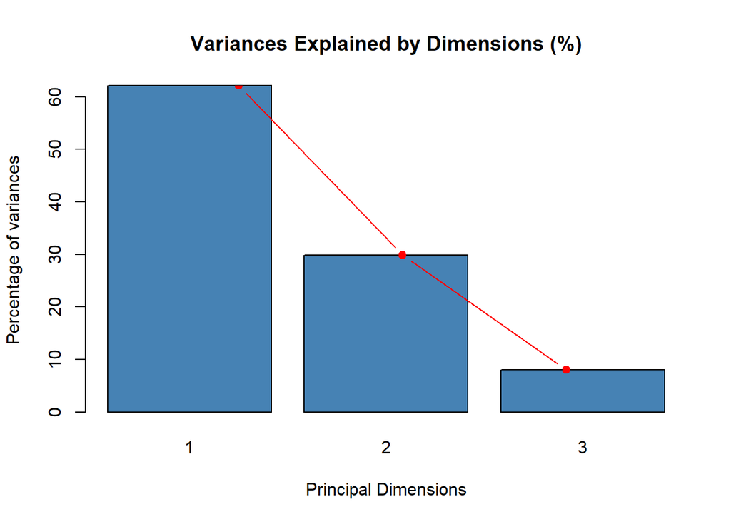

```r
barplot(eig.val[, 2],
        names.arg = 1:nrow(eig.val),
        main = "Variances Explained by Dimensions (%)",
        xlab = "Principal Dimensions",
        ylab = "Percentage of variances",
        col ="steelblue")
# Add connected line segments to the plot
lines(x = 1:nrow(eig.val), eig.val[, 2],
      type = "b", pch = 19, col = "red")
```

On remarque que le taux d’inertie cumulé des 2 premiers axes est de 92% ce qui est un taux important, on va donc conserver les 2 premiers axes.

### Représentation de la carte des profils-colonnes :

```r
round(cbind(res.ca$col$coord[,1:2],res.ca$col$contrib[,1:2], res.ca$col$cos2[,1:2]),2)
```

```
##                           Dim 1 Dim 2 Dim 1 Dim 2 Dim 1 Dim 2
## 1 à 2 fois par semaine    -0.04 -0.33  0.34 39.43  0.02  0.94
## 3 à 4 fois par semaine     0.03 -0.30  0.05  8.93  0.01  0.99
## Tous les 15 jours          1.15  0.07 64.34  0.54  0.95  0.00
## Tous les jours ou presque  0.30  0.51  5.64 33.77  0.20  0.58
## Tous les mois             -0.43  0.23 29.64 17.33  0.73  0.21
```

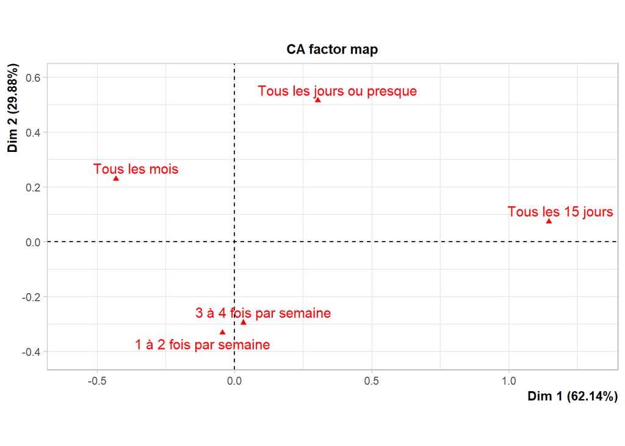

```r
plot(res.ca, invisible="row")
```

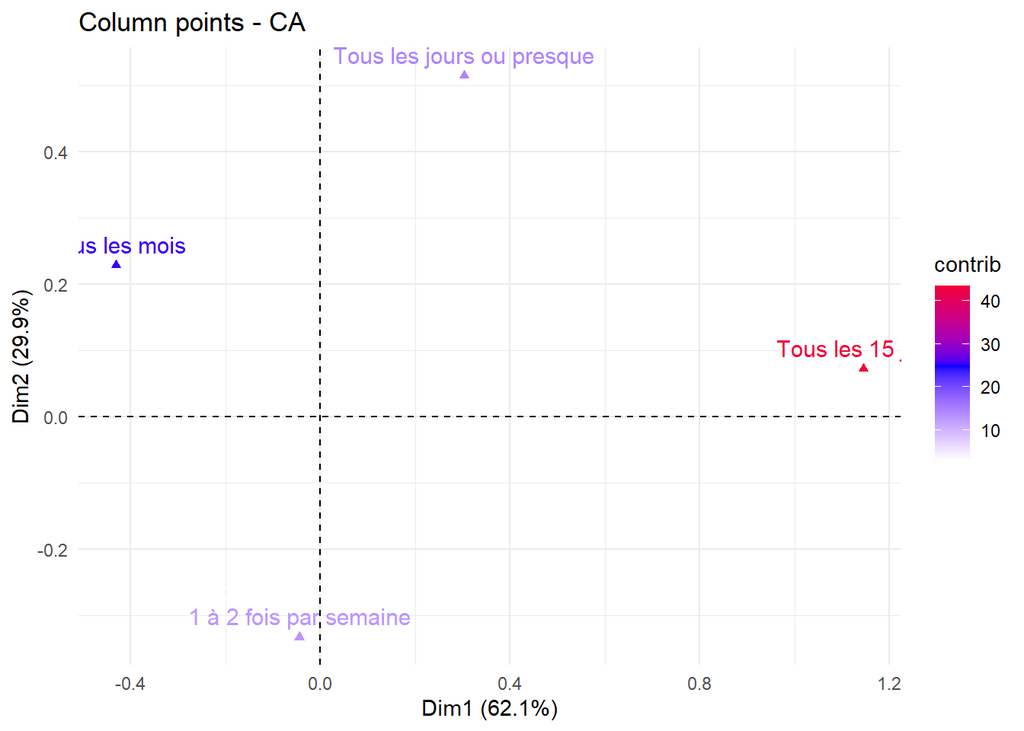

```r
fviz_ca_col(res.ca, col.col = "contrib")+
 scale_color_gradient2(low = "white", mid = "blue",
           high = "red", midpoint = 25) +theme_minimal()
```

### Représentation de la carte des profils-lignes :

```r
round(cbind(res.ca$row$coord[,1:2],res.ca$row$contrib[,1:2], res.ca$row$cos2[,1:2]),2)
```

```
##                    Dim 1 Dim 2 Dim 1 Dim 2 Dim 1 Dim 2
## Entre 18 et 25 ans -0.26 -0.08 15.97  3.44  0.73  0.08
## Entre 25 et 50 ans  0.78  0.06 74.05  0.87  0.99  0.01
## Moins de 18 ans    -0.19 -0.26  3.73 13.86  0.20  0.36
## Plus de 50 ans     -0.41  1.03  6.26 81.82  0.14  0.85
```

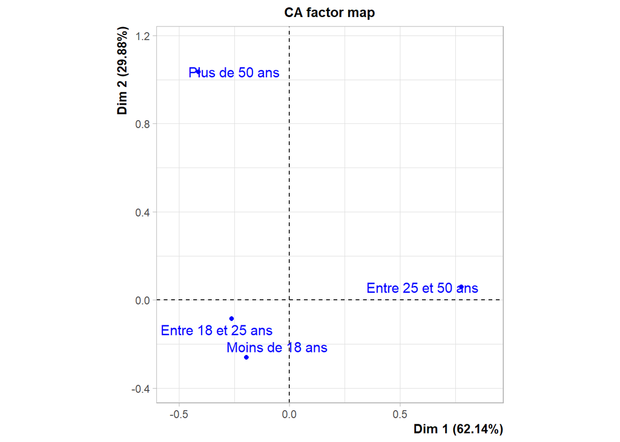

```r
plot(res.ca, invisible="col")
```

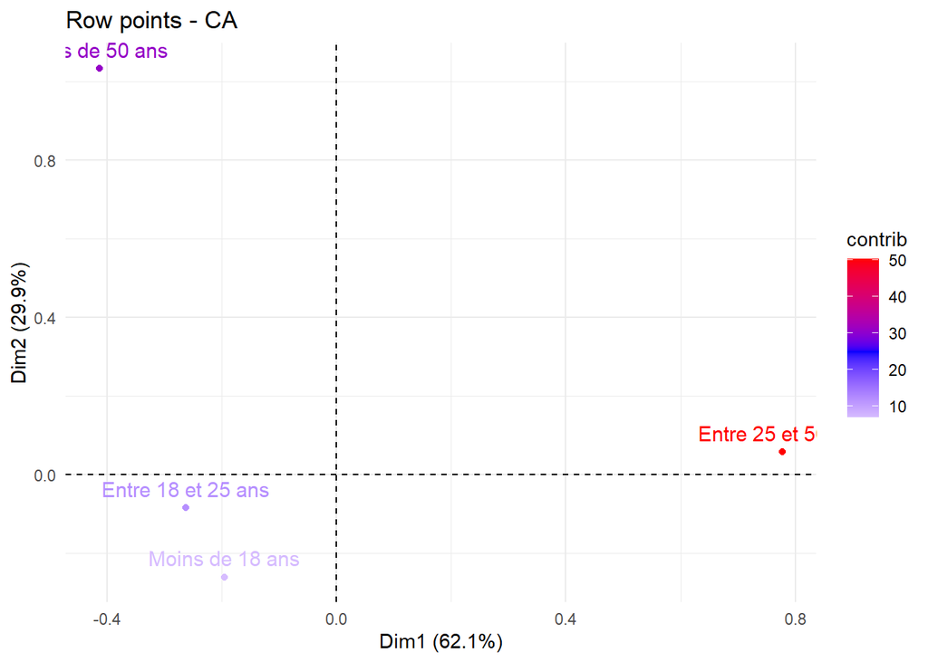

```r
# Cette carte permet de contrôler automatiquement la couleur selon la contribution

fviz_ca_row(res.ca, col.row = "contrib")+
 scale_color_gradient2(low = "white", mid = "blue",
           high = "red", midpoint = 25) +
 theme_minimal()
```

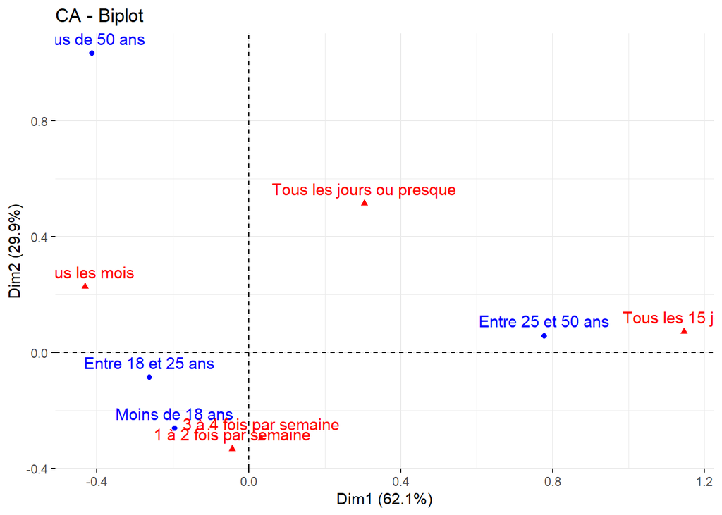

```r
# Biplot symétrique des lignes et des colonnes
fviz_ca_biplot(res.ca)
```

Ce Biplot montre une correspondance entre les variables “Entre 25 et 50 ans” et “Tous les 15 jours”, aussi entre “Moins de 18ans” et “3 à 4 fois par semaines” et ““1 à 2 fois par semaines”, etc…